# Hurónske jazero

### Všeobecný prístup pri modelovaní časových radov:

1. **zostrojiť graf ČR** a skúmať hlavné vlastnosti grafu, hľadať konkrétne, či obsahuje:
- *trend* – dlhodobé správanie sa hodnôt ČR (rast, pokles, stagnácia,…)
- *sezónnu zložku* – pravidelné kolísanie hodnôt okolo trendu s určitou periódou (vplyv ročných období, sviatkov, kultúrne zvyky…)
- *epizodickú zložku* - očividná „ostrá“ zmena v správaní (nepredvídateľný odklon od dlhodobého trendu v dôsledku náhlej udalosti – zemetrasenie, vojna, štrajk…)
- *odľahlé merania*
2. **Odstrániť tento trend a sezónnu zložku** a dostať tak reziduálnu (náhodnú) zložku, ktorá by už mala byť stacionárna (metódy sú efektívnejšie a výkonnejšie). Niekedy je potrebné urobiť predbežné transformácie (napr. logaritmickú)
3. **Vybrať model** aproximácie reziduálnej zložky s využitím rôznych výberových štatistík (napr. výberová ACF).
4. **Predikcia** pre reziduálnu zložku a spätnými transformáciami predpovede pre originálny ČR.

**Dáta v dátovom súbore LAKE.DAT predstavujú výšku hladiny Hurónskeho jazera nad 570 stôp v období 1875-1972**

### Odstránenie lineárneho trendu a zobrazenie reziduí - spracovanie v Exceli

- Načítame dáta z textového súboru Lake.dat.
- Doplníme stĺpec s aktuálnymi rokmi 1875 - 1972.
- Zobrazíme graf v Exceli (min na y-ovej osi nastaviť na 5).
- Popíšeme daný ČR
- V súlade s princípom úspornosti zvolíme lineárny trend.
- V Exceli vypíšeme hodnoty trendu
- Získame ČR reziduí
- Zobrazíme graficky reziduá v Exceli a pridáme trendovú čiaru

### Odstránenie lineárneho trendu a zobrazenie reziduí - spracovanie v R

#### Načítanie dát

```r
LAKE <- read.table("LAKE.DAT", quote="\"", comment.char="")
```

#### Načítanie premenných a zobrazenie ČR

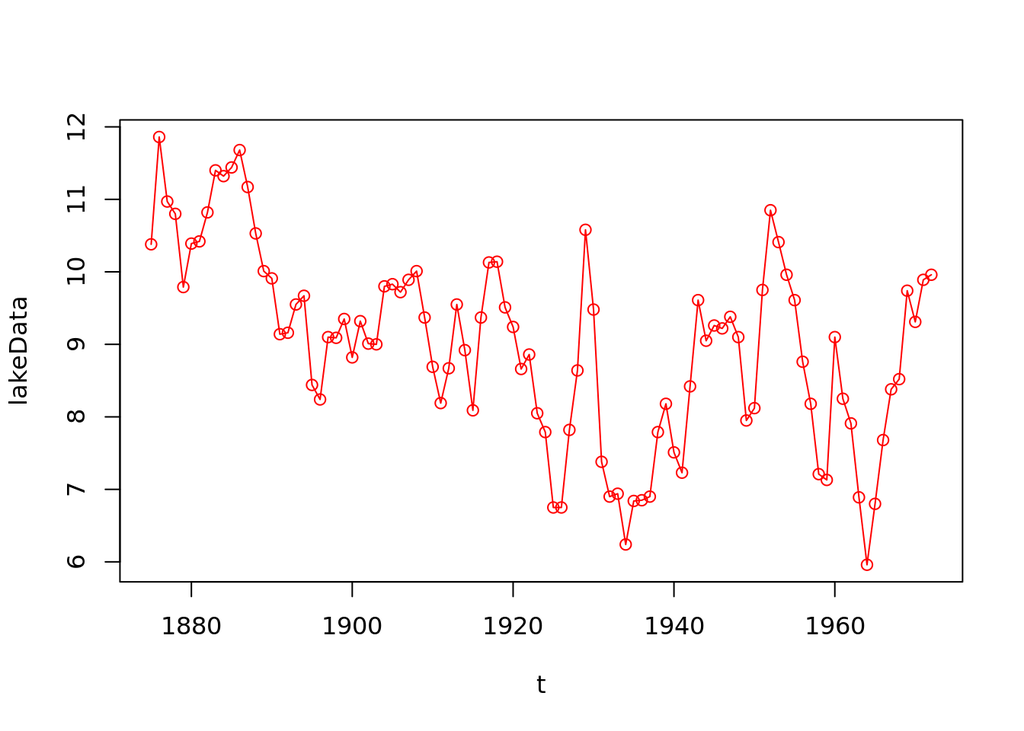

```r
lakeData <- LAKE$V1
lateTimeData <- ts(lakeData, start=1860, end=1980)
t <- 1875:1972
plot(t, lakeData, type='o', col='red')
```

#### Nájdenie rovnice lineárneho trendu a jeho grafické zobrazenie

Použijeme príkaz $lm$ ako *linear model* so syntaxou lm(čoJeZávislé~odČohoJeToZávislé).

```r
fitLakeData <- lm(lakeData~t)
coefficients(fitLakeData)
```

```
## (Intercept)           t
## 55.55491791 -0.02420111
```

#### Zobrazenie trendu do grafu

Preloženie dát priamkou z fitu.

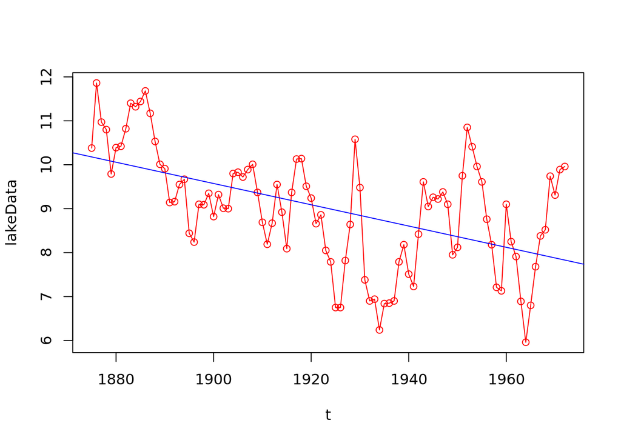

```r
plot(t, lakeData, type='o', col='red')
abline(fitLakeData, col='blue')
```

#### Získanie reziduí

Reziduá získame pomocou príkazu *residuals* a ako argument zoberieme náš fit.

```r
resLakeData <- residuals(fitLakeData)
show(resLakeData)
```

```
##           1           2           3           4           5           6
##  0.20216450  1.70636561  0.84056672  0.69476783 -0.29103106  0.33317006
##           7           8           9          10          11          12
##  0.38737117  0.81157228  1.41577339  1.35997450  1.50417561  1.76837672
##          13          14          15          16          17          18
##  1.28257783  0.66677894  0.17098005  0.09518116 -0.65061773 -0.60641662
##          19          20          21          22          23          24
## -0.19221551 -0.04801440 -1.25381329 -1.42961217 -0.54541106 -0.53120995
##          25          26          27          28          29          30
## -0.24700884 -0.75280773 -0.22860662 -0.51440551 -0.50020440  0.32399671
##          31          32          33          34          35          36
##  0.37819782  0.29239893  0.48660004  0.63080115  0.01500226 -0.64079663
##          37          38          39          40          41          42
## -1.11659552 -0.61239440  0.29180671 -0.31399218 -1.11979107  0.18441004
##          43          44          45          46          47          48
##  0.96861115  1.00281226  0.39701337  0.15121448 -0.40458441 -0.18038330
##          49          50          51          52          53          54
## -0.96618219 -1.20198108 -2.21777997 -2.19357886 -1.09937775 -0.25517663
##          55          56          57          58          59          60
##  1.70902448  0.63322559 -1.44257330 -1.89837219 -1.83417108 -2.50996997
##          61          62          63          64          65          66
## -1.88576886 -1.85156775 -1.77736664 -0.86316553 -0.44896442 -1.09476331
##          67          68          69          70          71          72
## -1.35056220 -0.13636109  1.07784002  0.54204114  0.77624225  0.76044336
##          73          74          75          76          77          78
##  0.94464447  0.68884558 -0.43695331 -0.24275220  1.41144891  2.53565002
##          79          80          81          82          83          84
##  2.11985113  1.69405224  1.36825335  0.54245446 -0.01334443 -0.95914332
##          85          86          87          88          89          90
## -1.01494221  0.97925891  0.15346002 -0.16233887 -1.15813776 -2.06393665
##          91          92          93          94          95          96
## -1.19973554 -0.29553443  0.42866668  0.59286779  1.83706890  1.43127001
##          97          98
##  2.03547112  2.12967223
```

#### Znázornenie reziduí

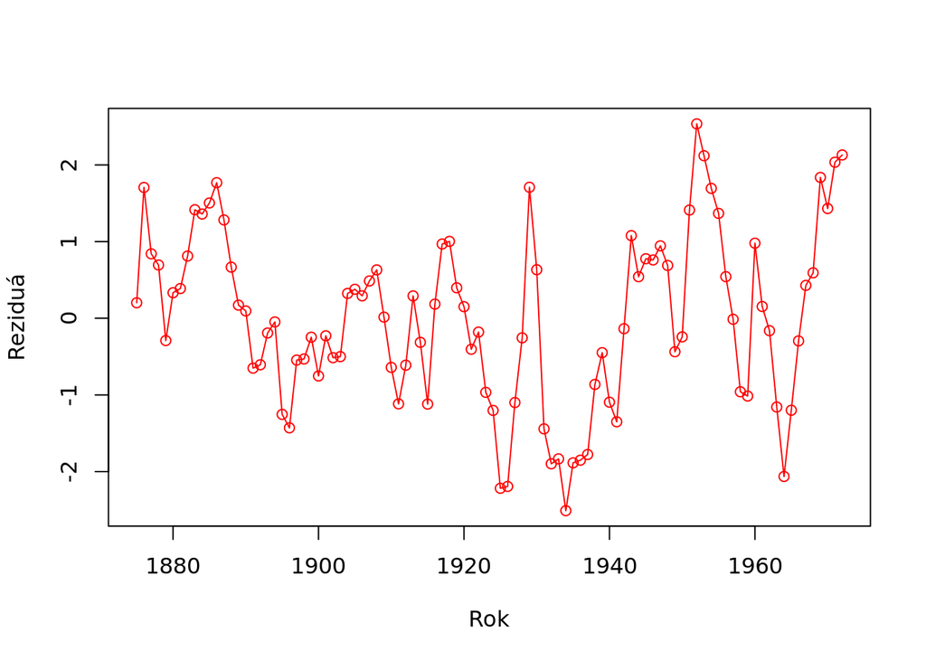

```r
plot(t, resLakeData, type='o', col='red', xlab='Rok', ylab = 'Reziduá')
```